# HW3: Exploring Gapminder with the tidyverse…part 2

Jenna Loesberg

9/29/2019

[Instructions are found here](https://stat545.stat.ubc.ca/evaluation/hw03/hw03/)

# Choosing three of the six tasks:

Include the folowing for each: 1. a tibble, using dplyr as your data manipulation tool; 2. an accompanying plot of data from the tibble, using ggplot2 as your visualization tool; and 3. some dialogue about what your tables/figures show (doesn’t have to be much).

## Task Option 2:

### Get the maximum and minimum of GDP per capita for all continents.

#### 1.1

Start by grouping by continent and using filter

```r
(gapminder2 <-
  gapminder %>%
  group_by(continent) %>%
  filter(gdpPercap==min(gdpPercap) | gdpPercap==max(gdpPercap)))
```

```
## # A tibble: 10 x 6
## # Groups:   continent [5]
##    country                continent  year lifeExp       pop gdpPercap
##    <fct>                  <fct>     <int>   <dbl>     <int>     <dbl>
##  1 Australia              Oceania    1952    69.1   8691212    10040.
##  2 Australia              Oceania    2007    81.2  20434176    34435.
##  3 Bosnia and Herzegovina Europe     1952    53.8   2791000      974.
##  4 Congo, Dem. Rep.       Africa     2002    45.0  55379852      241.
##  5 Haiti                  Americas   2007    60.9   8502814     1202.
##  6 Kuwait                 Asia       1957    58.0    212846   113523.
##  7 Libya                  Africa     1977    57.4   2721783    21951.
##  8 Myanmar                Asia       1952    36.3  20092996      331
##  9 Norway                 Europe     2007    80.2   4627926    49357.
## 10 United States          Americas   2007    78.2 301139947    42952.
```

#### 1.2

Now, making a plot. I want to make grouped columns, how do I do this??

There is definitly a better way to organize the data to be able to graph it, but this is what I figured out. I created a new column and identified the GDP as either min or max for each continent…

```r
gapminder2$key_gdp <- c('Min'
                          , 'Max'
                          , 'Min'
                          , 'Min'
                          , 'Min'
                          , 'Max'
                          , 'Max'
                          , 'Min'
                          , 'Max'
                          , 'Max')

gapminder2
```

```
## # A tibble: 10 x 7
## # Groups:   continent [5]
##    country               continent  year lifeExp      pop gdpPercap key_gdp
##    <fct>                 <fct>     <int>   <dbl>    <int>     <dbl> <chr>
##  1 Australia             Oceania    1952    69.1   8.69e6    10040. Min
##  2 Australia             Oceania    2007    81.2   2.04e7    34435. Max
##  3 Bosnia and Herzegovi~ Europe     1952    53.8   2.79e6      974. Min
##  4 Congo, Dem. Rep.      Africa     2002    45.0   5.54e7      241. Min
##  5 Haiti                 Americas   2007    60.9   8.50e6     1202. Min
##  6 Kuwait                Asia       1957    58.0   2.13e5   113523. Max
##  7 Libya                 Africa     1977    57.4   2.72e6    21951. Max
##  8 Myanmar               Asia       1952    36.3   2.01e7      331  Min
##  9 Norway                Europe     2007    80.2   4.63e6    49357. Max
## 10 United States         Americas   2007    78.2   3.01e8    42952. Max
```

And here is the grouped bar graph:

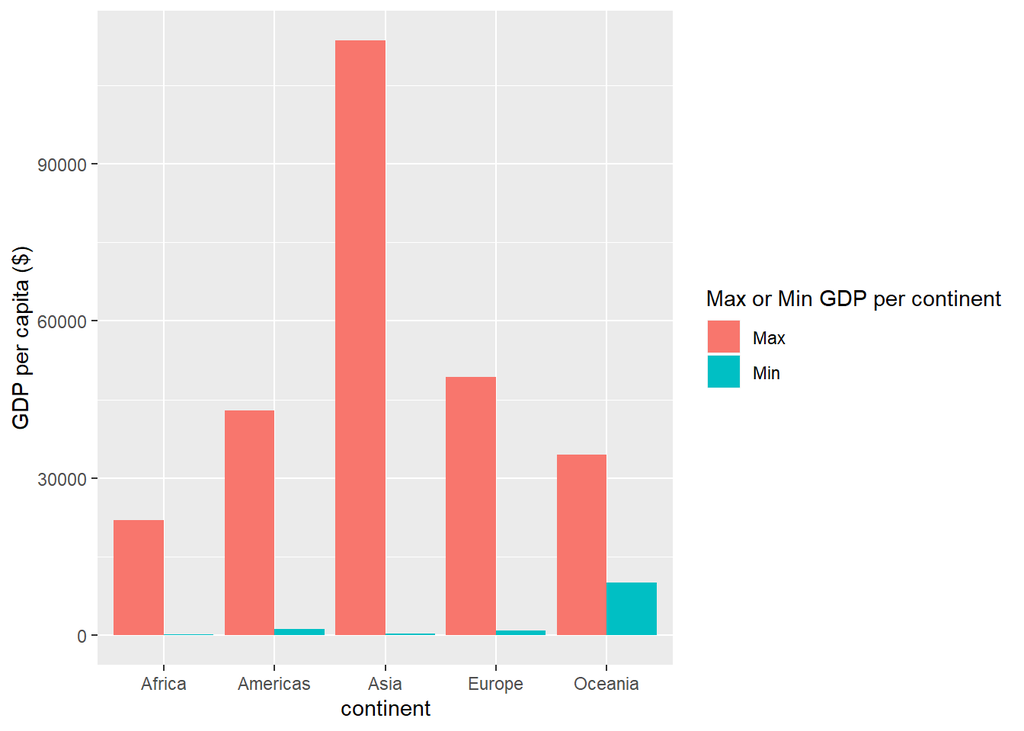

```r
gapminder2 %>%
  ggplot(aes(continent, gdpPercap, group = key_gdp, fill = key_gdp)) +
  geom_bar(stat="identity", position=position_dodge()) +
  labs(fill = "Max or Min GDP per continent") + #changing legend name
  ylab("GDP per capita ($)")
```

Again, there is likely a better way to do that…

#### 1.3

But now I can compare the minimum and maximum GDP for each continent in one plot (including data from all years). For most continents, there is a drastic difference between the max and min GDP. The mins are all pretty low, and for Asia, the max is very high.

## Task Option 3:

### Look at the spread of GDP per capita within the continents

#### 2.1

Tibble looking at spread:

```r
gapminder %>%
  group_by(continent) %>%
  summarize(min_GDP = min(gdpPercap), mean_GDP = mean(gdpPercap), median_GDP = median(gdpPercap), max_GDP = max(gdpPercap), sd_GDP = sd(gdpPercap))
```

```
## # A tibble: 5 x 6
##   continent min_GDP mean_GDP median_GDP max_GDP sd_GDP
##   <fct>       <dbl>    <dbl>      <dbl>   <dbl>  <dbl>
## 1 Africa       241.    2194.      1192.  21951.  2828.
## 2 Americas    1202.    7136.      5466.  42952.  6397.
## 3 Asia         331     7902.      2647. 113523. 14045.
## 4 Europe       974.   14469.     12082.  49357.  9355.
## 5 Oceania    10040.   18622.     17983.  34435.  6359.
```

But this includes all data points across many years, If I wanted to look specifically at variance across time, I could make:

#### 2.2

Boxplots for each year’s GDP across continents

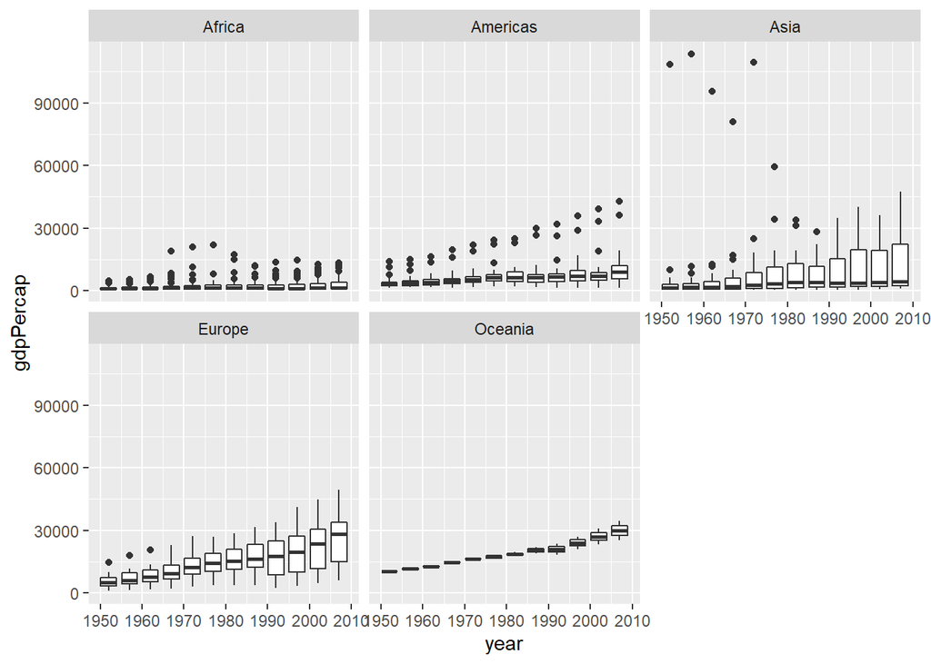

```r
gapminder %>%
  group_by(continent) %>%
  ggplot(aes(year, gdpPercap, group = year)) +
  geom_boxplot() +
  facet_wrap(~ continent)
```

#### 2.3

Well, it doesn’t look great. But tells an interesting story. GDP is increasing for most continents except for Africa. Lots of variance in Asia (few very large values), and very little variance in Oceania.

## Task Option 5

#### How is life expectancy changing over time on different continents?

#### 3.1/2

I’m just going to go straight into a boxplot, because a table won’t be that interesting:

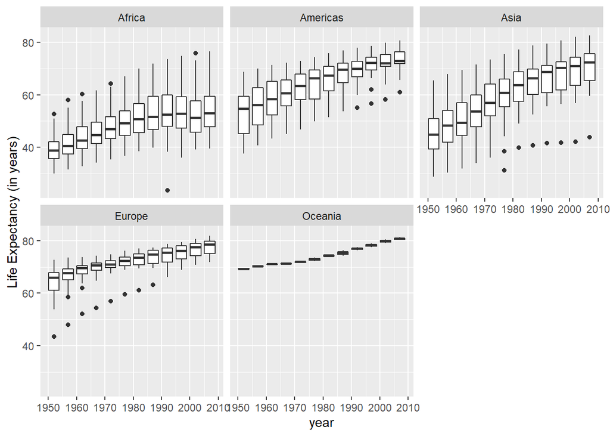

```r
gapminder %>%
  group_by(continent) %>%
  ggplot(aes(year, lifeExp, group = year)) +
  geom_boxplot() +
  facet_wrap(~ continent)+
  ylab("Life Expectancy (in years)")
```

### 3.3

Life expectancy is increasing thorughout time. But Africa’s is plateauing. Europe’s variance is decreasing over time, not sure if I can say that about Asia or America.